# ARIMA Model for Utilities Sector Fund

During exploratory data analysis (EDA), it was observed that the raw data is often non-stationary, exhibiting trends, seasonality, and other complex patterns that can make modeling and forecasting difficult. To address this issue, the data is often differentiated to achieve stationarity, which is a key assumption of the ARIMA model.

Differencing involves calculating the difference between each data point and the previous data point, which can help to remove trends and seasonality from the data. The goal is to create a new series of data that is stationary, meaning that the statistical properties of the data do not change over time.

#### Differentiated Time Series Plot

**Plot**

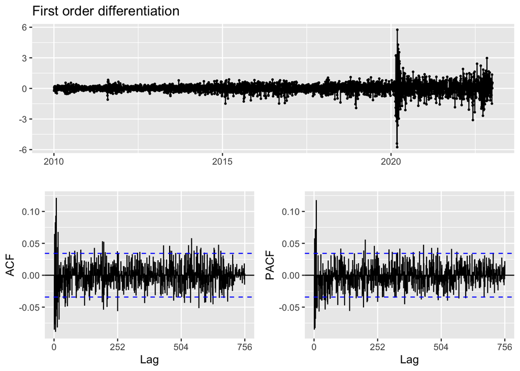

```r
#import the data
df <- read.csv("DATA/CLEANED DATA/XLU_raw_data.csv")
#convert to time series data
myts<-ts(df$XLU.Adjusted,frequency=252,start=c(2010,1,1), end = c(2023,3,1))
#First order differentiation
df1 <- diff(myts)
# Plot
myts  %>% diff() %>% ggtsdisplay(main = "First order differentiation")
```

**ACF**

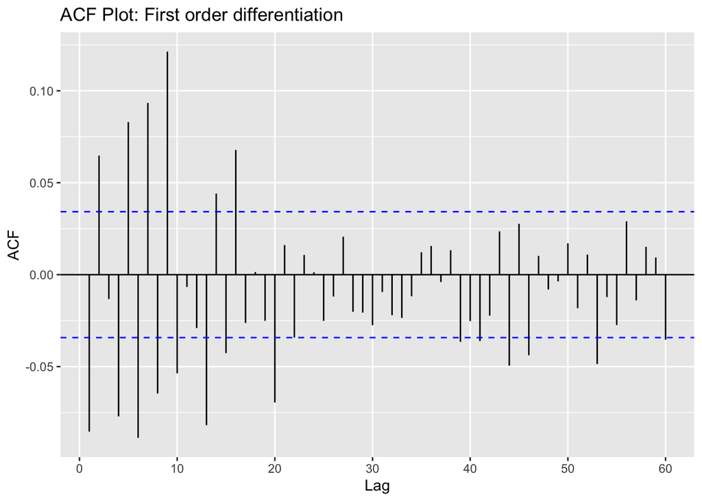

```r
#ACF plot
ggAcf(df1,60,main="ACF Plot: First order differentiation")
```

**PACF**

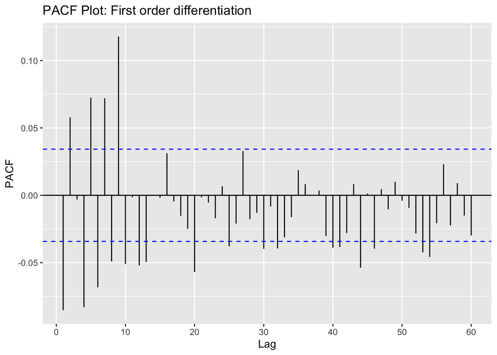

```r
ggPacf(df1,60,main="PACF Plot: First order differentiation")
```

**ADF Test**

```r
tseries::adf.test(df1)
```

```
    Augmented Dickey-Fuller Test

data:  df1
Dickey-Fuller = -15.702, Lag order = 14, p-value = 0.01
alternative hypothesis: stationary
```

After analyzing the ACF and PACF plots, it can be observed that most of the bar lines lie between the blue lines, indicating that the time series is stationary. This has been further confirmed through an Augmented Dickey-Fuller test as the p-value is less than 0.05. Once the data is stationary, the next step is to model it using ARIMA. The combination of ACF and PACF plots can help determine the appropriate values for p, d, and q in the ARIMA model. The order of differencing required to achieve stationarity gives the d value. The p value is determined by examining significant spikes at various lags in the PACF plot, while the q value is determined through significant spikes in the ACF plot. It is important to consider other methods such as grid search and information criteria to ensure the most appropriate model is selected.

Here the parameters are d = 1 p = 0,9 (PACF Plot) q = 0,9 (ACF Plot)

#### Model Selection

**ARIMA(0,1,0) Result**

```r
Arima(myts,order=c(0,1,0),include.drift=TRUE)
```

```
Series: myts
ARIMA(0,1,0) with drift

Coefficients:
       drift
      0.0155
s.e.  0.0090

sigma^2 = 0.2669:  log likelihood = -2485.69
AIC=4975.37   AICc=4975.38   BIC=4987.56
```

**ARIMA(9,1,0) Result**

```r
Arima(myts,order=c(9,1,0),include.drift=TRUE)
```

```
Series: myts
ARIMA(9,1,0) with drift

Coefficients:
          ar1     ar2     ar3      ar4     ar5      ar6     ar7      ar8
      -0.0552  0.0417  0.0000  -0.0828  0.0718  -0.0601  0.0634  -0.0421
s.e.   0.0173  0.0174  0.0173   0.0173  0.0173   0.0173  0.0174   0.0174
         ar9   drift
      0.1179  0.0155
s.e.  0.0174  0.0093

sigma^2 = 0.2547:  log likelihood = -2405
AIC=4832   AICc=4832.08   BIC=4899.04
```

**ARIMA(9,1,9) Result**

```r
Arima(myts,order=c(9,1,9),include.drift=TRUE)
```

```
Series: myts
ARIMA(9,1,9) with drift

Coefficients:
          ar1     ar2      ar3      ar4      ar5     ar6      ar7      ar8
      -0.3311  0.3528  -0.4807  -1.1841  -0.4268  0.0256  -0.1490  -0.5778
s.e.   0.1624  0.2935   0.1519   0.2882   0.5276  0.2699   0.3303   0.1196
          ar9     ma1      ma2     ma3     ma4     ma5     ma6     ma7     ma8
      -0.3263  0.2793  -0.3212  0.5307  1.0766  0.4447  0.0015  0.1837  0.5359
s.e.   0.2495  0.1599   0.2873  0.1613  0.2724  0.5351  0.2084  0.3143  0.1441
         ma9   drift
      0.3921  0.0150
s.e.  0.2200  0.0088

sigma^2 = 0.2518:  log likelihood = -2381.61
AIC=4803.22   AICc=4803.48   BIC=4925.12
```

**ARIMA(0,1,9) Result**

```r
Arima(myts,order=c(0,1,9),include.drift=TRUE)
```

```
Series: myts
ARIMA(0,1,9) with drift

Coefficients:
          ma1     ma2     ma3      ma4     ma5      ma6     ma7      ma8
      -0.0511  0.0451  0.0073  -0.0783  0.0864  -0.0794  0.0671  -0.0362
s.e.   0.0174  0.0173  0.0173   0.0175  0.0180   0.0181  0.0174   0.0168
         ma9   drift
      0.0963  0.0155
s.e.  0.0180  0.0093

sigma^2 = 0.2559:  log likelihood = -2412.45
AIC=4846.91   AICc=4846.99   BIC=4913.95
```

**Auto Arima Model**

```r
auto.arima(myts)
```

```
Series: myts
ARIMA(2,1,0) with drift

Coefficients:
          ar1     ar2   drift
      -0.0804  0.0579  0.0155
s.e.   0.0174  0.0174  0.0088

sigma^2 = 0.2642:  log likelihood = -2468.21
AIC=4944.42   AICc=4944.43   BIC=4968.8
```

#### Model Diagnostic

**Model Plot**

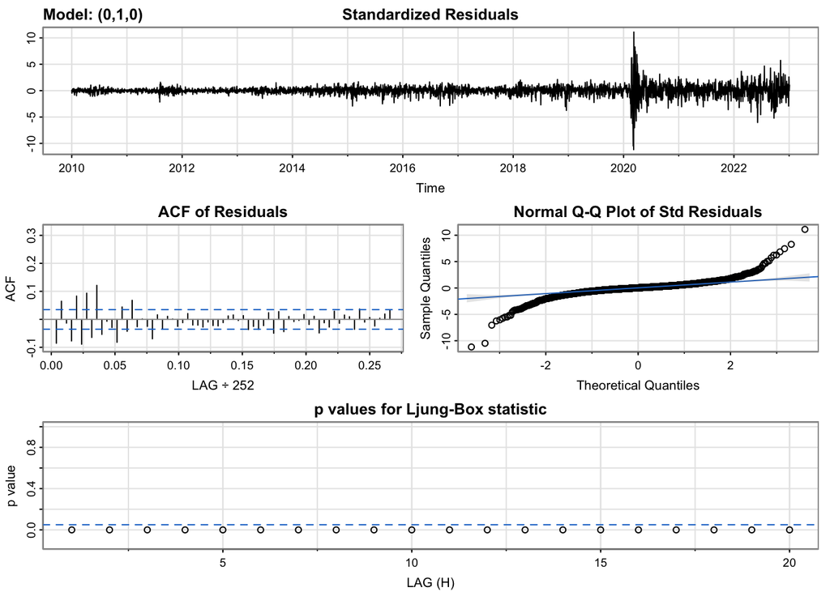

```r
model_output <- capture.output(sarima(myts,0,1,0))
```

**Model**

```r
cat(model_output[9:38], model_output[length(model_output)], sep = "\n")
```

```
$fit

Call:
arima(x = xdata, order = c(p, d, q), seasonal = list(order = c(P, D, Q), period = S),
    xreg = constant, transform.pars = trans, fixed = fixed, optim.control = list(trace = trc,
        REPORT = 1, reltol = tol))

Coefficients:
      constant
        0.0155
s.e.    0.0090

sigma^2 estimated as 0.2668:  log likelihood = -2485.69,  aic = 4975.37

$degrees_of_freedom
[1] 3277

$ttable
         Estimate    SE t.value p.value
constant   0.0155 0.009  1.7165  0.0862

$AIC
[1] 1.517807

$AICc
[1] 1.517808

$BIC
[1] 1.521526
```

#### Forcast

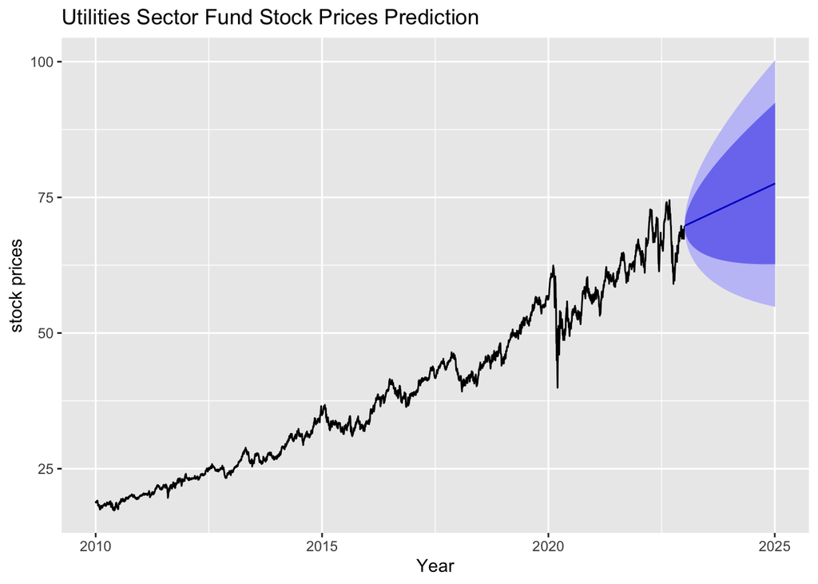

```r
myts %>%
  Arima(order=c(0,1,0),include.drift = TRUE) %>%
  forecast %>%
  autoplot(main = "Utilities Sector Fund Stock Prices Prediction") +
  ylab("stock prices") + xlab("Year")
```

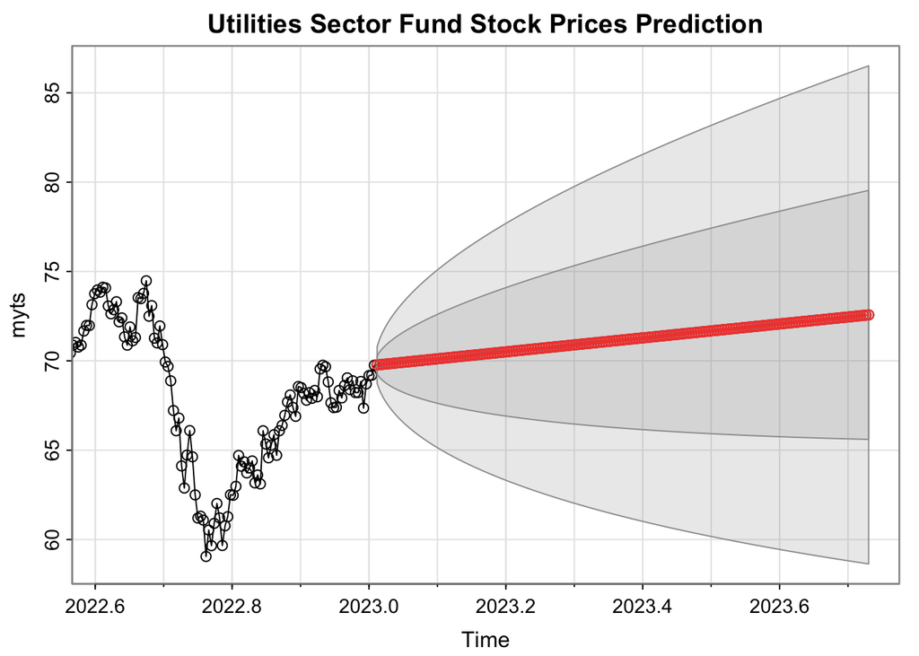

```
$pred
Time Series:
Start = c(2023, 4)
End = c(2023, 185)
Frequency = 252
  [1] 69.76949 69.78498 69.80046 69.81595 69.83143 69.84692 69.86240 69.87789
  [9] 69.89338 69.90886 69.92435 69.93983 69.95532 69.97080 69.98629 70.00178
 [17] 70.01726 70.03275 70.04823 70.06372 70.07920 70.09469 70.11017 70.12566
 [25] 70.14115 70.15663 70.17212 70.18760 70.20309 70.21857 70.23406 70.24954
 [33] 70.26503 70.28052 70.29600 70.31149 70.32697 70.34246 70.35794 70.37343
 [41] 70.38892 70.40440 70.41989 70.43537 70.45086 70.46634 70.48183 70.49731
 [49] 70.51280 70.52829 70.54377 70.55926 70.57474 70.59023 70.60571 70.62120
 [57] 70.63668 70.65217 70.66766 70.68314 70.69863 70.71411 70.72960 70.74508
 [65] 70.76057 70.77606 70.79154 70.80703 70.82251 70.83800 70.85348 70.86897
 [73] 70.88445 70.89994 70.91543 70.93091 70.94640 70.96188 70.97737 70.99285
```

[output cut: 45 more lines]

```r
sarima.for(myts,182, 0,1,0, main='Utilities Sector Fund Stock Prices Prediction')
```

The two figures above show an idea of the short term and the long-term forecasted stock price. The forecasted values is be based on the estimated parameters of the model, which were obtained by fitting it to the historical data. One way to assess the accuracy of the forecasts is to use cross-validation, which involves splitting the data into training and testing sets and comparing the predicted values to the actual values in the test set. This can help to identify any potential problems with the model and to fine-tune the model parameters.

**12 Step ahead Cross Validation**

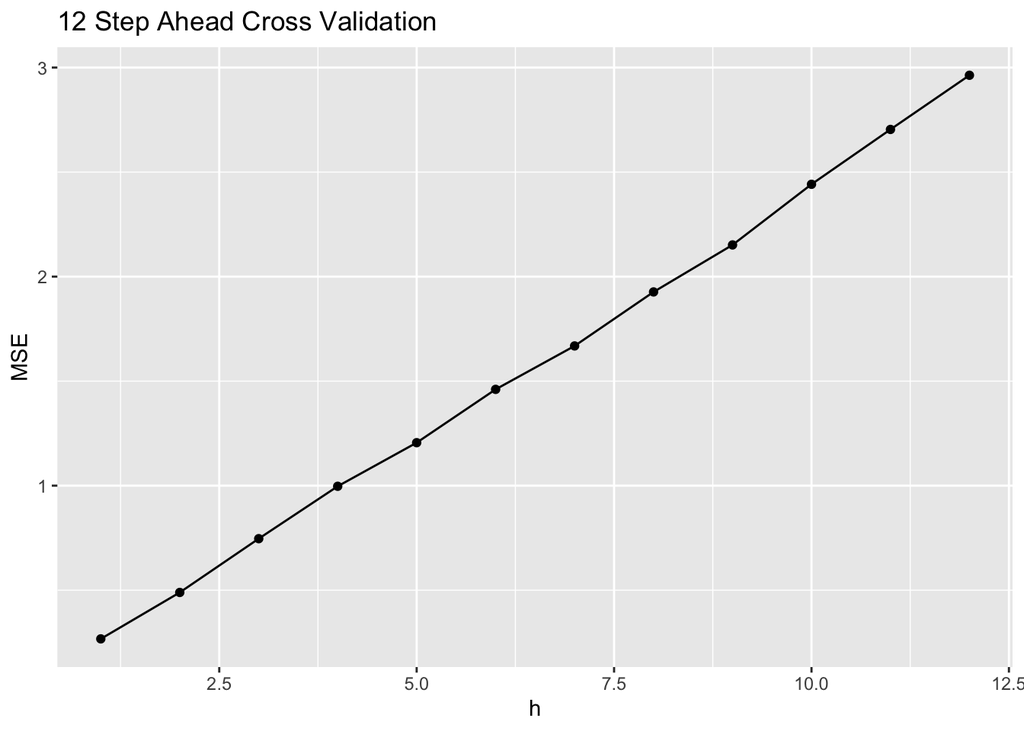

```r
#a seasonal cross validation using 12 steps ahead forecasts
farima1 <- function(x, h){forecast(Arima(x, order=c(0,1,0)), h=h)}

# Compute cross-validated errors for up to 12 steps ahead
e <- tsCV(myts, forecastfunction = farima1, h = 12)

# Compute the MSE values and remove missing values
mse <- colMeans(e^2, na.rm = TRUE)

# Plot the MSE values against the forecast horizon
data.frame(h = 1:12, MSE = mse) %>%
  ggplot(aes(x = h, y = MSE)) + geom_point()+geom_line()+ggtitle("12 Step Ahead Cross Validation")
```

**1 Step ahead Cross Validation**

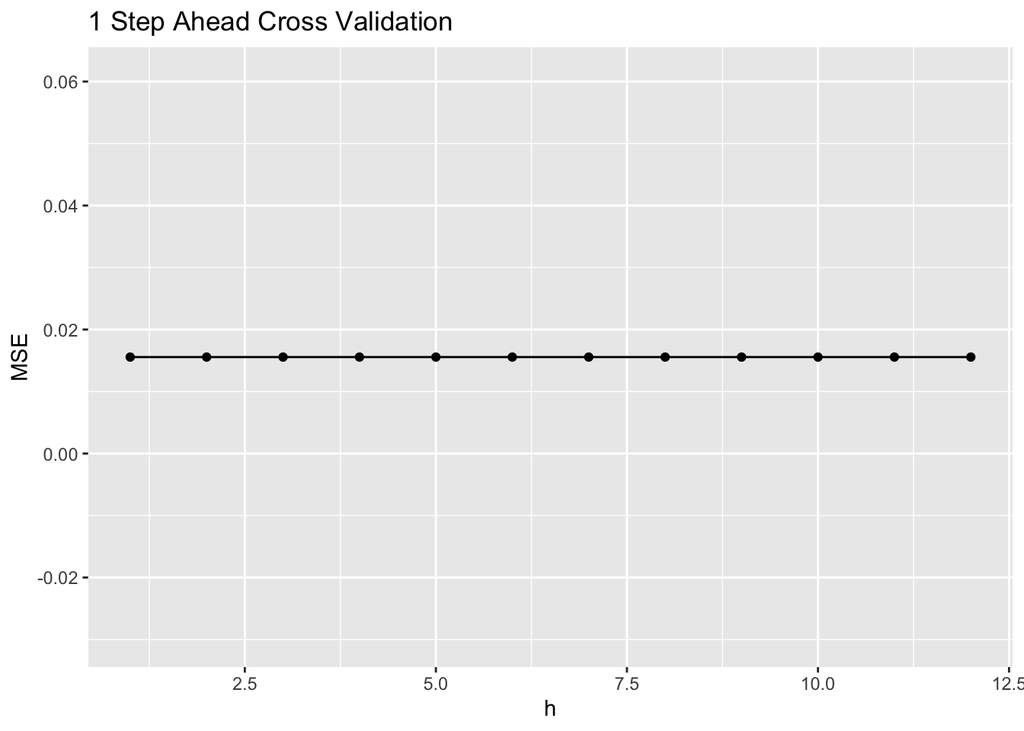

```r
#a seasonal cross validation using 1 steps ahead forecasts
farima1 <- function(x, h){forecast(Arima(x, order=c(0,1,0)),h=h)}

# Compute cross-validated errors for up to 1 steps ahead
e <- tsCV(myts, forecastfunction = farima1, h = 1)
mse <-abs(mean(e,na.rm=TRUE))

# Plot the MSE values against the forecast horizon
data.frame(h = 1:12, MSE = mse) %>%
  ggplot(aes(x = h, y = MSE)) + geom_point()+geom_line()+ggtitle("1 Step Ahead Cross Validation")
```

The one-step-ahead forecasting plot shows that the MSE seems to be stable. The MSE is tend to rise by 12 steps at each step of cross-validation. Lastly, the above-mentioned ARIMA model should be compared to benchmark methods before being used for a long time.

#### Model Comparison

**Plot**

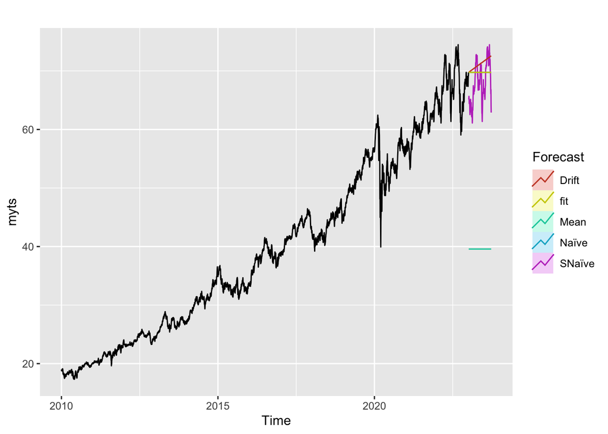

```r
fit <- Arima(myts, order=c(0,1,0))
autoplot(myts) +
  autolayer(meanf(myts, h=182),
            series="Mean", PI=FALSE) +
  autolayer(naive(myts, h=182),
            series="Naïve", PI=FALSE) +
  autolayer(snaive(myts, h=182),
            series="SNaïve", PI=FALSE)+
  autolayer(rwf(myts, h=182, drift=TRUE),
            series="Drift", PI=FALSE)+
  autolayer(forecast(fit,182),
            series="fit",PI=FALSE) +
  guides(colour=guide_legend(title="Forecast"))
```

**Model Error Table**

```r
summary <- summary(fit)
snaive <- snaive(myts, h=182)
accuracy(snaive)
```

```
                   ME     RMSE      MAE      MPE     MAPE MASE      ACF1
Training set 4.032984 5.327367 4.329826 9.786299 10.44789    1 0.9775654
```

```r
summary
```

```
Series: myts
ARIMA(0,1,0)

sigma^2 = 0.267:  log likelihood = -2487.16
AIC=4976.32   AICc=4976.32   BIC=4982.41

Training set error measures:
                     ME      RMSE       MAE        MPE      MAPE       MASE
Training set 0.01548667 0.5166714 0.3138152 0.03344792 0.7580014 0.07247755
                    ACF1
Training set -0.08532622
```

[output not shown]